# (G)LMMs Visualization: why and how

## Just in case you need motivation

Caveats:

- I'm using data from real, recent papers but
- Material here doesn't attempt to replicate or criticize

## LMM: "Simple" greenhouse, linear mixed model

## Pattern and amount – cool question!

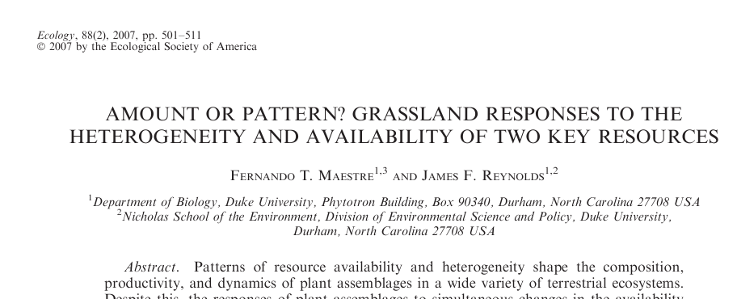

## 4 (!) treatments – full factorial blocked

```r
xtabs(~ water_hetero + water_add + nutrient_hetero + nutrient_add + block , d)
```

```
## , , nutrient_hetero = heterogeneous, nutrient_add = 120 mg N, block = 1
##
##              water_add
## water_hetero  125 mL 250 mL 375 mL
##   homogeneous      1      1      1
##   pulse            1      1      1
##
## , , nutrient_hetero = homogeneous, nutrient_add = 120 mg N, block = 1
##
##              water_add
## water_hetero  125 mL 250 mL 375 mL
##   homogeneous      1      1      1
##   pulse            1      1      1
##
## , , nutrient_hetero = heterogeneous, nutrient_add = 40 mg N, block = 1
##
##              water_add
## water_hetero  125 mL 250 mL 375 mL
##   homogeneous      1      1      1
##   pulse            1      1      1
##
## , , nutrient_hetero = homogeneous, nutrient_add = 40 mg N, block = 1
##
##              water_add
## water_hetero  125 mL 250 mL 375 mL
##   homogeneous      1      1      1
##   pulse            1      1      1
##
## , , nutrient_hetero = heterogeneous, nutrient_add = 80 mg N, block = 1
##
##              water_add
## water_hetero  125 mL 250 mL 375 mL
##   homogeneous      1      1      1
##   pulse            1      1      1
##
## , , nutrient_hetero = homogeneous, nutrient_add = 80 mg N, block = 1
##
##              water_add
## water_hetero  125 mL 250 mL 375 mL
##   homogeneous      1      1      1
```

[output cut: 112 more lines]

```
##   pulse            1      1      1
##
## , , nutrient_hetero = heterogeneous, nutrient_add = 80 mg N, block = 4
##
##              water_add
## water_hetero  125 mL 250 mL 375 mL
##   homogeneous      1      1      1
##   pulse            1      1      1
##
## , , nutrient_hetero = homogeneous, nutrient_add = 80 mg N, block = 4
##
##              water_add
## water_hetero  125 mL 250 mL 375 mL
##   homogeneous      1      1      1
##   pulse            1      1      1
```

## GLMM: Lizard mate choice

## Mechanisms of speciation – cool question!

- mate compatibility trails
- western North American skinks (*Plestiodon skiltonianus* spp)
- Richmond, J. Q., E. L. Jockusch, and A. M. Latimer 2010. Mechanical reproductive isolation facilitates parallel speciation in western North American scincid lizards. *American Naturalist*

## Repeated measure ind, multiple trials, binary choice

```r
xtabs(~ Series + Female , data=d2, sparse=TRUE)
```

```
## 15 x 75 sparse Matrix of class "dgCMatrix"
```

```
##    [[ suppressing 75 column names '1', '2', '3' ... ]]
```

```
##
## 1  . 3 . . . . . . . . . . . . . . . . 3 . . . . . . . . . . . . . . 3 . .
## 2  2 . . . . . 2 . . . . . . . . . . . . . . . . . . . 2 2 . . . . . . . 2
## 3  . . . 1 . . . . . . . . . . 1 . . . . . 2 . . . . . . . . 1 . . . . . .
## 4  . . . . . . . . . . . . 3 . . 3 . . . 3 . . . . . 3 . . . . . . . . . .
## 5  . . . . . . . . . . 1 3 . 1 3 . . 3 . . . 2 . . 2 . . . . 3 . . . . . .
## 7  . . . . 3 . . . . . . . . 2 2 . 2 . . . 1 . . . . . . . . . . 1 . . . .
## 8  . . . . . . . . . . . . . . . . . . . . . . . . . . . . . . . . . . . .
## 9  . . . . . . . . . . . . . . . . . . . . . . . . . . . . . . . . 1 . . .
## 10 . . . . . . . . . . . . . . . . . . . . . . . . . . . . 2 . . . . . . .
## 11 . . . . . . . . . . . . . . . . . . . 1 . . . . . . . . . . . . . . . .
## 12 . . 4 . . . . . . 4 . . . . . . . . 1 1 . . . . . . . . . . 2 . . . . .
## 13 . . . . . . . . . . . . . . . . . . . . . . . . . . . . . . . . . . . .
## 14 . . . . . . . . 1 . . . . . . . . . . . . . . . . . . . . . . 3 . . . .
## 15 . . . . . . . 3 . . . . . . . . . . . . . . . . . . . . . . . . . . . .
```

[output cut: 33 more lines]

## how do we

- fit models that accommodate hierarchy and error distribution?
- criticize these models?
- infer or generalize the models (graphically)?
- illustrate predictions?

## Preliminaries

## learning resources: stats

Do you *really* need….

- HLM? Murtaugh 2007 *Ecology* 88(1):56-62)
- Poisson GLM? Ives 2015 "For testing the significance of regression coefficients, go ahead and log-transform count data" *Methods in Ecology and Evolution*

How do you design your MM study?

- Schielzeth & Nakagawa 2013 *Methods in Ecology and Evolution* 4:14-24, Baayen, Davidson, & Bates 2008 *Journal of Memory and Language* 59:390-412

What if you only speak ANOVA?

- Stroup 2015 *Agronomy Journal* 107(2):811-827

## computing resources: `r`

```r
# + first in R, best (?) documented,
# + easy to fit correlation structures in RE
# - linear
library(nlme)
# + long-running R ME project, fastest, still supported
# - correlation structures, bootstraping
library(lme4)
# + more flexible, r interface to auto-differentiation library in C++
# - less documented, fewer examples
library(glmmADMB)
```

## Today

- criticize these models?
- infer or generalize the models (graphically)?
- illustrate predictions?

## emphasis

- working with frequentist libraries for (G)LMM in R
- visualization for: criticism, inference, prediction

## three facets

- quick diagnostic viz (plots *native* to fitting packages)
- slower model criticism (also *native*)
- inference & prediction (lightweight external libs / export capabilities)

## where do I learn this stuff?

## I. In the console

```r
methods(class='merMod')
```

```
##  [1] anova.merMod*        as.function.merMod*  augment.merMod*
##  [4] coef.merMod*         confint.merMod       deviance.merMod*
##  [7] df.residual.merMod*  drop1.merMod*        extractAIC.merMod*
## [10] family.merMod*       fitted.merMod*       fixef.merMod*
## [13] formula.merMod*      fortify.merMod       glance.merMod*
## [16] isGLMM.merMod*       isLMM.merMod*        isNLMM.merMod*
## [19] isREML.merMod*       logLik.merMod*       model.frame.merMod*
## [22] model.matrix.merMod* ngrps.merMod*        nobs.merMod*
## [25] plot.merMod*         predict.merMod*      print.merMod*
## [28] profile.merMod*      qqmath.merMod*       ranef.merMod*
## [31] refit.merMod*        refitML.merMod*      residuals.merMod*
## [34] sigma.merMod*        simulate.merMod*     summary.merMod*
## [37] terms.merMod*        tidy.merMod*         update.merMod*
## [40] VarCorr.merMod*      vcov.merMod          weights.merMod*
##
##    Non-visible functions are asterisked
```

## II. From papers & books …

- Pinheiro & Bates 2000 *Mixed-effects models in S and S-PLUS* Springer, New York
- [Bates' `lme4` book draft](http://lme4.r-forge.r-project.org/book/)
- [the lme4 paper](http://arxiv.org/abs/1406.5823):

```r
citation(package='lme4')
```

```
##
## Bates D, Maechler M, Bolker B and Walker S (2014). _lme4: Linear
## mixed-effects models using Eigen and S4_. R package version 1.1-7,
## <URL: http://CRAN.R-project.org/package=lme4>.
##
## Bates D, Maechler M, Bolker BM and Walker S (2014). "lme4: Linear
## mixed-effects models using Eigen and S4." ArXiv e-print; submitted
## to _Journal of Statistical Software_, <URL:
## http://arxiv.org/abs/1406.5823>.
```

## III. … and the Internet

- [GLMM wiki FAQ](http://glmm.wikidot.com/faq)
- Ben Bolker's forthcoming chapter on "Worked examples" [available on Rpubs](https://rpubs.com/bbolker/glmmchapter)
- StackOverflow Q&A
- …

## Back to code

code walk through